# Machine Learning Course Project

Kyle Jarrod McLean

September 21, 2014

### Load Libraries

The following libraries were used for the analysis:

```r
library(magrittr)
library(dplyr)
library(caret)
library(ggplot2)
library(gridExtra)
library(randomForest)
```

### Load training data

```r
fulldata <- read.csv("pml-training.csv")
```

### Data Processing

```r
colcut1 <- fulldata[, c(2:160)]
```

Next, the data was inspected for NAs. The following code indentified columns containg more that 5% NAs and stripped the whole column from the dataset. The resulting dataframe, colcut2, is decreased to 92 columns from 159.

```r
#identify rows with more than 95% NA
NA_filter <- apply(colcut1, 2, l(x ~ x %>% is.na %>% which %>% length %>%
                                      divide_by(19622) %>%
                                      is_less_than(0.05)))
#remove the mostly NA rows
colcut2 <- colcut1[, NA_filter]
```

Surprisingly, removing the > 95% NA columns removed all NAs from the dataset, so there is no need for imputation.

Next, the nearZeroVar function was used to determine which columns displayed near zero variation across all samples. Such columns would expect to be of little to no relevance to the outcome. 34 columns were determined to be near zero, and these were cut from the data, leaving the dataframe colcut3 with 58 columns.

```r
#identify "near zero" columns
nearZero <- nearZeroVar(colcut2, saveMetrics = TRUE)
#remove these near zero columns
colcut3 <- colcut2[, -(nearZero[, 4] %>% which)]
```

Visual inspection of the remaining columns revealed that columns 2 through 4 were timestamp variables. These three columns were also stripped from the data, resulting in dataframe colcut4 with 54 predictors columns and one outcome column.

```r
colcut4 <- colcut3[, -c(2:4)]
```

The names of colcut4 were then used to subset the original data file, ‘fulldata’. This ‘column_filter’ variable will be used later to subset pml-testing.csv file.

```r
column_filter <- names(colcut4)
filtered_data <- fulldata[, column_filter]
```

### Data Partitioning

The 19622 data points of the filtered_data were randomly split 60%/40% into a training and testing data set in order to implement and evaluate a prediction model. Note that this “testing” set is not the pml-testing.csv file. Herein, that file is referred to as ‘validation’.

```r
set.seed(1234)
inTrain  <- createDataPartition(filtered_data$classe, p = 0.60, list = FALSE)
training <- filtered_data[inTrain, ] # 55 columns, 11776 rows
testing  <- filtered_data[-inTrain, ] # 55 columns, 7846 rows
```

### Model Implementation

Since this is a classification problem, it was decided that a random forest model would be most suitable, as these models are quite robust on large data sets such as this. The randomForest() function was used from the randomForest library. The functions defaults were left as is, including the default ntree setting of 500.

```r
set.seed(1234)
modFit <- randomForest(x = training[, -55], y = training[, 55])
```

### Out-of-bag Error and Cross Validation

The results of the model building are as follows:

```
##
## Call:
##  randomForest(x = training[, -55], y = training[, 55])
##                Type of random forest: classification
##                      Number of trees: 500
## No. of variables tried at each split: 7
##
##         OOB estimate of  error rate: 0.45%
## Confusion matrix:
##      A    B    C    D    E class.error
## A 3347    0    0    0    1   0.0002987
## B   10 2267    2    0    0   0.0052655
## C    0   16 2036    2    0   0.0087634
## D    0    0   15 1914    1   0.0082902
## E    0    0    0    6 2159   0.0027714
```

Due to the resampling inherent to Random Forest, the Out-of-Bag (OOB) error is essentially equivalent to a cross-validation. Here, the OOB is estimated at 0.45%. As shown above, each class is estimated from the training data with less than 1% error.

```r
cv <- rfcv(trainx = training[, -55], trainy = training[, 55])
cv_df <- cbind(n.var = cv$n.var, error.cv = cv$error.cv) %>% data.frame
```

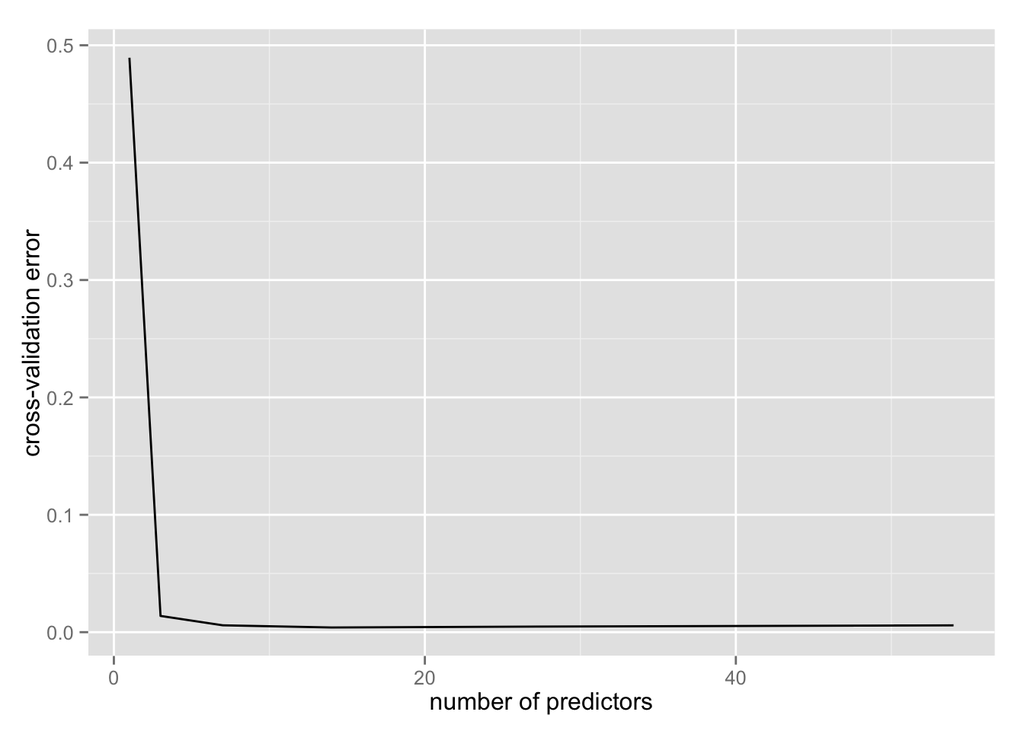

```r
ggplot(cv_df, aes(cv$n.var, cv$error.cv)) + geom_line() + ylab("cross-validation error") +
    xlab("number of predictors")
```

### Accuracy

To independently assess the accuracy of the model, the model was predicted on the 7846-row testing data set described above (ie: not the pml-testing.csv data).

```r
#predict on testing values
pred <- predict(modFit, testing)
confusionMatrix(pred, testing$classe)
```

```
## Confusion Matrix and Statistics
##
##           Reference
## Prediction    A    B    C    D    E
##          A 2232    5    0    0    0
##          B    0 1510    4    0    0
##          C    0    3 1363   10    0
##          D    0    0    1 1275    2
##          E    0    0    0    1 1440
##
## Overall Statistics
##
##                Accuracy : 0.997
##                  95% CI : (0.995, 0.998)
##     No Information Rate : 0.284
##     P-Value [Acc > NIR] : <2e-16
##
##                   Kappa : 0.996
##  Mcnemar's Test P-Value : NA
##
## Statistics by Class:
##
##                      Class: A Class: B Class: C Class: D Class: E
## Sensitivity             1.000    0.995    0.996    0.991    0.999
## Specificity             0.999    0.999    0.998    1.000    1.000
## Pos Pred Value          0.998    0.997    0.991    0.998    0.999
## Neg Pred Value          1.000    0.999    0.999    0.998    1.000
## Prevalence              0.284    0.193    0.174    0.164    0.184
## Detection Rate          0.284    0.192    0.174    0.163    0.184
## Detection Prevalence    0.285    0.193    0.175    0.163    0.184
## Balanced Accuracy       1.000    0.997    0.997    0.995    0.999
```

As displayed above, the model shows a very high accuracy of 99.66% (99.5-99.77%).

### Importance

The importance of each variable used in the creation of the model as calculated by the random forest are displayed below:

```r
imp_values <- data.frame(modFit$importance)
importance <- cbind(rownames(imp_values), imp_values)
colnames(importance) <- c("variable", "meanGini")
importance %<>% arrange(., desc(meanGini))
importance
```

```
##                variable meanGini
## 1            num_window   780.77
## 2             roll_belt   689.30
## 3              yaw_belt   506.46
## 4         pitch_forearm   456.92
## 5     magnet_dumbbell_z   415.10
## 6            pitch_belt   399.09
## 7     magnet_dumbbell_y   398.30
## 8          roll_forearm   306.67
## 9     magnet_dumbbell_x   270.51
## 10         accel_belt_z   243.58
## 11        roll_dumbbell   238.29
## 12     accel_dumbbell_y   236.53
## 13        magnet_belt_z   215.40
## 14        magnet_belt_y   211.37
```

[output cut: 40 more lines]

The predictors “num_ value” and “roll_ belt” are by far the most important predictors in the model.

### Predicting on the Unknown Validation Data

The unknown validation data was loaded into the workspace and filtered down to only the necessary columns in the following manner:

```r
full_validation <- read.csv("pml-testing.csv")
validation <- full_validation[, column_filter[-55]]
```

The Random Forest model was then used to predict the values of the data:

```r
pred_v <- predict(modFit, validation)
pred_v
```

```
##  1  2  3  4  5  6  7  8  9 10 11 12 13 14 15 16 17 18 19 20
##  B  A  B  A  A  E  D  B  A  A  B  C  B  A  E  E  A  B  B  B
## Levels: A B C D E
```

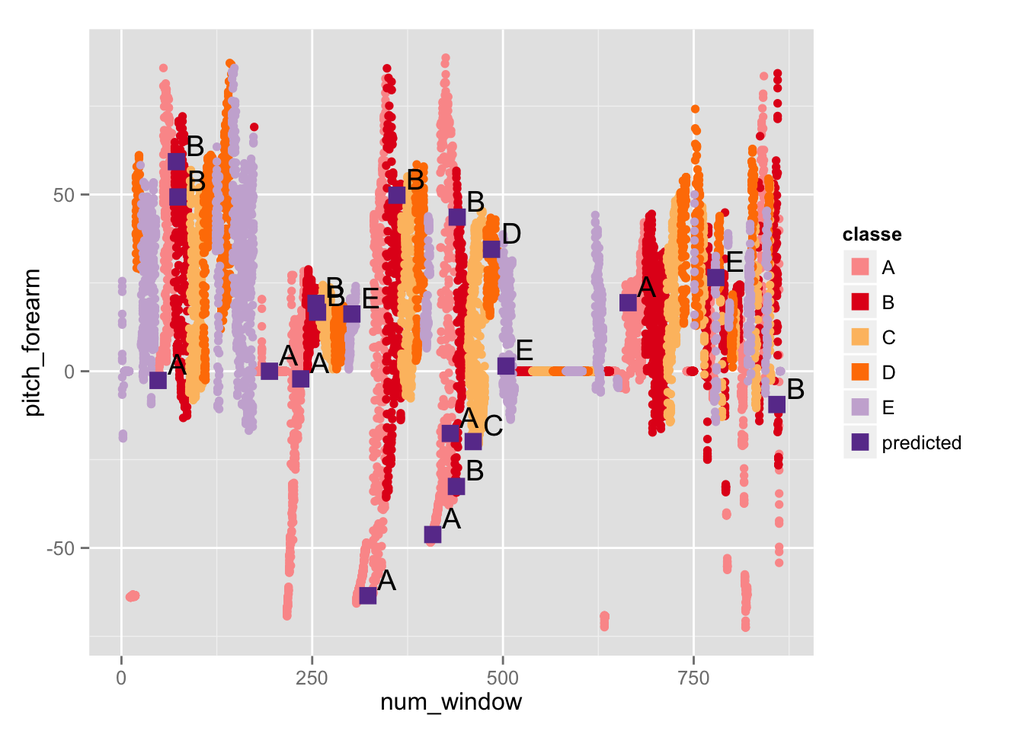